# Preparation for Exercise 2 - Diving In with the Titanic Data

Sigal Shaked

March 27, 2017

### Background

In this exercise, you will practice your new R skills based on a real machine learning task. You will:

1. Load data from files
2. Use graphs to get a better understanding of the data
3. Create a machine learning model based on the data, and use it for prediction.

### The Data

We will use the titanic data, based on kaggle’s [Machine Learning from Disaster](https://www.kaggle.com/c/titanic) competition. The titanic sank after colliding with an iceberg, killing 1502 out of 2224 passengers and crew. Although there was some element of luck involved in surviving the sinking, some groups of people were more likely to get on a lifeboat than others, such as women, children and upper-class. In this task, you will apply the tools of machine learning to predict which passengers survived the tragedy.

### Variables Description:

| Feature | Description |
| --- | --- |
| survival | Survival (0 = No; 1 = Yes) |
| pclass | Passenger Class (1 = 1st; 2 = 2nd; 3 = 3rd) |
| name | Name |
| sex | Sex |
| age | Age |
| sibsp | Number of Siblings/Spouses Aboard |
| parch | Number of Parents/Children Aboard |
| ticket | Ticket Number |
| fare | Passenger Fare |
| cabin | Cabin |
| embarked | Port of Embarkation (C = Cherbourg; Q = Queenstown; S = Southampton) |

## Getting Started

### Requirements:

Install R if you still haven’t: https://cran.r-project.org/bin/windows/base/

Then install Rstudio’s “desktop edition” from this link: https://www.rstudio.com/products/rstudio/#Desktop

### Your Tasks:

1. Open a new RScript. (ctrl+shift+N)
2. Decide where you want to put your files and set this folder as a working directory.
3. Read the train.csv file into a dataframe. Use the parameter na.strings = “” to recognize empty strings as null values, otherwise these empty strings might raise errors when creating a model.
4. Check the datatypes of the attributes using the *str* method. You should find two numeric features that must be converted into factors. Convert these two features to factors.
5. Produce some descriptive statistics using the *Summary* method, and read it to get to know your data. Do you have missing data(NA) inside? If so, you should either preprocess the data to have non NAs, or use only models that can handle missing values. We will go with the second option, so you don’t need to preprocess the data for now.
6. It seems that the following features have too many categories or simply represent an index: PassengerId, Ticket, Name. You should either extract some stronger feature out of it (like getting honorific abbreviations out of the name: Mrs., Dr. etc.), or ignore these features. We will go with the second option; Remove these features from your dataframe.
7. (*Non-mandatory) Visualize the behavior of each feature vs. the target feature (surviving or not). View your graphs to gain an understanding which of the features explain the target feature.
8. Split the data into 75% train and 25% test sets.
9. Train a C5.0 decision-tree model based on the train data.
10. Predict the target feature for records of the test set, using the trained model.
11. Produce a confusion matrix between predicted target attributes and real target attributes of the test set.
12. Calculate the model’s test accuracy.
13. (Non-mandatory) Now train the same model using the caret package. This time set up a 10-fold cross validation configuration instead of the train-test split that was used before. (No need to set any parameters for the model, go with its default tuning grid). Set the *na.action* to “na.pass” in order for caret to pass NAs to C5.0 instead of failing. Check the model’s average test accuracy, and the parameter values that gave the best accuracy.
14. Load the test file. Don’t forget the empty strings issue when loading the file (na.strings = “”).
15. Create a vector with the PassengerIds of records in the test file. We will soon attach it to the prediction results.
16. Repeat the same preprocessing steps that were performed on the train data (factorizing two features and ignoring three features). You must make sure that the train and test data have the same structure (except for the target feature)
17. Another thing that is going to make troubles is that the test data contains some new levels in the *Cabin* feature that did not appear in the train data (you can check it by applying *Summary* on the test data). Add these new levels to the model.
- Getting the levels of the “Cabin” feature from a model *m*: m$xlevels[[“Cabin”]]
- Getting the levels of the “Cabin” feature from a dataframe *d*: levels(d$Cabin)
- Union operation: union(x,y)
18. Load the test file and predict the target attribute for its records using your trained model. Don’t forget to set *na.action* to “na.pass” if you used caret in the model creation, otherwise it will fail.
19. Write the *PassengerId* and *Survived* attributes to a csv file and submit this file to kaggle’s competition (You should first subscribe to the site). What is your score?
20. Keep trying to improve your score by tuning parameters or by training other models. You can also try to do some data engineering and extract some relevant data from the features that we dumped. Those who enters the top 50 in the leaderboard, will get to be our champions ;)

## Solutions:

1. Open a new RScript. (ctrl+shift+N)
2. Decide where you want to put your files and set this folder as a working directory.

For your RScript:

```r
#setwd('C:\\Users\\sigal\\OneDrive - post.bgu.ac.il\\sigal\\build courses\\leumi\\Class2')
```

For rmarkdown:

```r
#knitr::opts_knit$set(root.dir = 'C:/Users/sigal/OneDrive - post.bgu.ac.il/sigal/build #courses/leumi/Class2')
#getwd()
```

3. Read the train.csv file into a dataframe. Use the parameter na.strings = “” to recognize empty strings as null values, otherwise these empty strings might raise errors when creating a model.

```r
df <- read.csv("Titanic/train.csv",na.strings = "")
```

4. Check the datatypes of the attributes using the *str* method. You should find two numeric features that must be converted into factors. Convert these two features to factors.

```r
str(df)
```

```
## 'data.frame':    891 obs. of  12 variables:
##  $ PassengerId: int  1 2 3 4 5 6 7 8 9 10 ...
##  $ Survived   : int  0 1 1 1 0 0 0 0 1 1 ...
##  $ Pclass     : int  3 1 3 1 3 3 1 3 3 2 ...
##  $ Name       : Factor w/ 891 levels "Abbing, Mr. Anthony",..: 109 191 358 277 16 559 520 629 417 581 ...
##  $ Sex        : Factor w/ 2 levels "female","male": 2 1 1 1 2 2 2 2 1 1 ...
##  $ Age        : num  22 38 26 35 35 NA 54 2 27 14 ...
##  $ SibSp      : int  1 1 0 1 0 0 0 3 0 1 ...
##  $ Parch      : int  0 0 0 0 0 0 0 1 2 0 ...
##  $ Ticket     : Factor w/ 681 levels "110152","110413",..: 524 597 670 50 473 276 86 396 345 133 ...
##  $ Fare       : num  7.25 71.28 7.92 53.1 8.05 ...
##  $ Cabin      : Factor w/ 147 levels "A10","A14","A16",..: NA 82 NA 56 NA NA 130 NA NA NA ...
##  $ Embarked   : Factor w/ 3 levels "C","Q","S": 3 1 3 3 3 2 3 3 3 1 ...
```

```r
df$Survived<- as.factor(df$Survived)
df$Pclass<- as.factor(df$Pclass)
```

5. Produce some descriptive statistics using the *Summary* method, and read it to get to know your data. Do you have missing data(NA) inside? If so, you should either preprocess the data to have non NAs, or use only models that can handle missing values. We will go with the second option, so you don’t need to preprocess the data for now.

```r
summary(df)
```

```
##   PassengerId    Survived Pclass
##  Min.   :  1.0   0:549    1:216
##  1st Qu.:223.5   1:342    2:184
##  Median :446.0            3:491
##  Mean   :446.0
##  3rd Qu.:668.5
##  Max.   :891.0
##
##                                     Name         Sex           Age
##  Abbing, Mr. Anthony                  :  1   female:314   Min.   : 0.42
##  Abbott, Mr. Rossmore Edward          :  1   male  :577   1st Qu.:20.12
##  Abbott, Mrs. Stanton (Rosa Hunt)     :  1                Median :28.00
##  Abelson, Mr. Samuel                  :  1                Mean   :29.70
##  Abelson, Mrs. Samuel (Hannah Wizosky):  1                3rd Qu.:38.00
##  Adahl, Mr. Mauritz Nils Martin       :  1                Max.   :80.00
##  (Other)                              :885                NA's   :177
##      SibSp           Parch             Ticket         Fare
##  Min.   :0.000   Min.   :0.0000   1601    :  7   Min.   :  0.00
##  1st Qu.:0.000   1st Qu.:0.0000   347082  :  7   1st Qu.:  7.91
##  Median :0.000   Median :0.0000   CA. 2343:  7   Median : 14.45
##  Mean   :0.523   Mean   :0.3816   3101295 :  6   Mean   : 32.20
##  3rd Qu.:1.000   3rd Qu.:0.0000   347088  :  6   3rd Qu.: 31.00
##  Max.   :8.000   Max.   :6.0000   CA 2144 :  6   Max.   :512.33
##                                   (Other) :852
##          Cabin     Embarked
##  B96 B98    :  4   C   :168
##  C23 C25 C27:  4   Q   : 77
##  G6         :  4   S   :644
##  C22 C26    :  3   NA's:  2
##  D          :  3
##  (Other)    :186
##  NA's       :687
```

6. It seems that the following features have too many categories or simply represent an index: PassengerId, Ticket, Name. You should either extract some stronger feature out of it (like getting honorific abbreviations out of the name: Mrs., Dr. etc.), or ignore these features. We will go with the second option; Remove these features from your dataframe.

```r
df <- df[,-c(1,4,9)]
```

7. (*Non-mandatory) Visualize the behavior of each feature vs. the target feature (surviving or not). View your graphs to gain an understanding which of the features explain the target feature.

It is easier to explore factors and numeric features separately. Here we divide the features’ names to numerics and factors:

```r
cols<- 1:dim(df)[2]
factors <- cols[sapply(df,is.factor)]
numerics <- cols[!sapply(df,is.factor)]
```

We now tide the data two times: the first is for categorial data and the second for numeric data.

```r
#install.packages("tidyr")
library(tidyr)
df_tidy_factors<-gather(df[,factors],"feature","value",-1)
df_tidy_numerics<-gather(cbind(Survived=df[,1],df[,numerics]),"feature","value",-1)
```

Finally, we can plot. The first plot describes only categorical features (factors). Notice that the *scales* parameter was set to “free” to enable a suitable scaling for each facet (otherwise it is hard to view some of the facets, that need much smaller scales). We use the *facet_grid* that accepts a *scales* parameter.

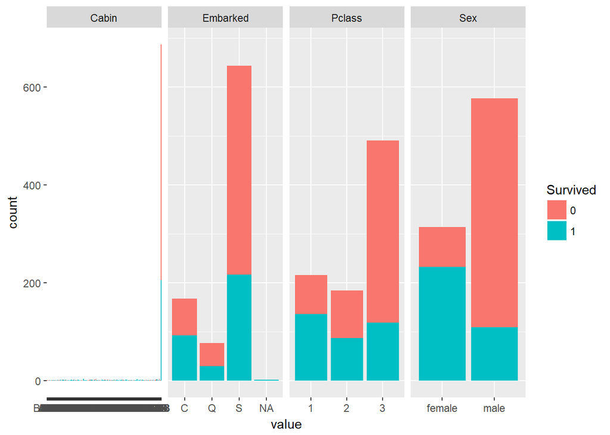

```r
#install.packages("ggplot2")
library(ggplot2)
qplot(x=value,data=df_tidy_factors,fill=Survived) + facet_grid(~feature,scales="free")
```

One more plot for numeric features:

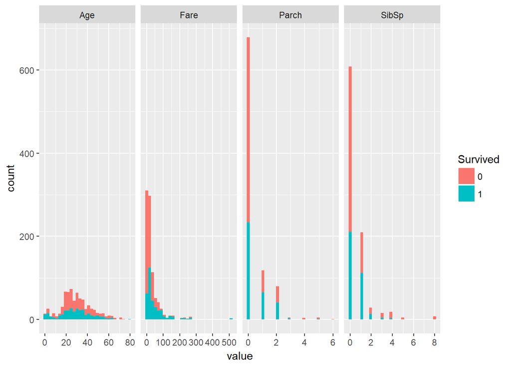

```r
qplot(x=value,data=df_tidy_numerics,fill=Survived) + facet_grid(~feature,scales="free")
```

It certainly looks luck there are more chances to survive in certain levels of almost each feature.

8. Split the data into 75% train and 25% test sets.

```r
indices <- sample(1:nrow(df),nrow(df)*0.75)
train<- df[indices,]
test<- df[-indices,]
```

9. Train a C5.0 decision-tree model based on the train data.

```r
#install.packages(C50)
library(C50)
set.seed(123)
C50 <-C5.0(Survived ~., data=train )
```

[figure not shown]

```r
plot(C50)
```

10. Predict the target feature for records of the test set, using the trained model.

```r
pred <- predict(C50,test)
```

11. Produce a confusion matrix between predicted target attributes and real target attributes of the test set.

```r
table(pred,test$Survived)
```

```
##
## pred   0   1
##    0 122  36
##    1   7  58
```

12. Calculate the model’s test accuracy.

```r
mean(pred==test$Survived)
```

```
## [1] 0.8071749
```

13. (Non-mandatory) Now train the same model using the caret package. This time set up a 10-fold cross validation configuration instead of the train-test split that was used before. (No need to set any parameters for the model, go with its default tuning grid). Set the *na.action* to “na.pass” in order for caret to pass NAs to C5.0 instead of failing. Check the model’s average test accuracy, and the parameter values that gave the best accuracy.

```r
#install.packages("caret")
library(caret)
set.seed(123)
control <- trainControl(method="cv", number=10)
fit.c50 <- train(Survived~., data=df, method="C5.0", metric="Accuracy", trControl=control,na.action = na.pass)
fit.c50
```

[output not shown]

14. Load the test file. Don’t forget the empty strings issue when loading the file (na.strings = “”).

```r
new_df <-read.csv('Titanic/test.csv',na.strings = "")
```

15. Create a vector with the PassengerIds of records in the test file. We will soon attach it to the prediction results.

```r
ids<- new_df$PassengerId
```

16. Repeat the same preprocessing steps that were performed on the train data (factorizing two features and ignoring three features). You must make sure that the train and test data have the same structure (except for the target feature)

```r
new_df$Pclass<- as.factor(new_df$Pclass)
new_df<- new_df[,-c(1,3,8)]
```

17. Another thing that is going to make troubles is that the test data contains some new levels in the *Cabin* feature that did not appear in the train data (you can check it by applying *Summary* on the test data). Add these new levels to the model.
- Getting the levels of the “Cabin” feature from a model *m*: m$xlevels[[“Cabin”]]
- Getting the levels of the “Cabin” feature from a dataframe *d*: levels(d$Cabin)
- Union operation: union(x,y)

```r
fit.c50$xlevels[["Cabin"]] <- union(fit.c50$xlevels[["Cabin"]], levels(new_df$Cabin))
```

18. Load the test file and predict the target attribute for its records using your trained model. Don’t forget to set *na.action* to “na.pass” if you used caret in the model creation, otherwise it will fail.

```r
new_pred<- predict(fit.c50,new_df,na.action = na.pass)
```

19. Write the *PassengerId* and *Survived* attributes to a csv file and submit this file to kaggle’s competition (You should first subscribe to the site). What is your score?

```r
res <- cbind(PassengerId=ids,Survived=as.character(new_pred))
write.csv(res,file="Titanic/try1.csv",row.names = F)
```

That puts us around no. 3300 in the leaderboard with a 0.77990 accuracy score. :(

20. Keep trying to improve your score by tuning parameters or by training other models. You can also try to do some data engineering and extract some relevant data from the features that we dumped.

#### The last item is actually your next homework assignment. The full requirements will be forthcoming soon.